## **3<sup>rd</sup> WEEK**: Logistic regression

### Introduction

Data including grades, demographic, social and school related features were collected in two Portuguese schools using school reports and questionnaires and stored as two separate datasets regarding performance in distinct subjects, namely Mathematics and Portuguese.

The original data of the analysis in this exercise are freely available as a [zip file](https://archive.ics.uci.edu/ml/machine-learning-databases/00320/). Additional [metadata](https://archive.ics.uci.edu/ml/datasets/Student+Performance) information describes basic characteristics of the data sets. For the purpose of this particular exercise they needed to be joined and edited according to [this R script](https://github.com/paap0/IODS-project/blob/master/data/create_alc.R). The variables not used for joining the two data sets were combined by averaging them. An additional variable *high_use* was created by taking the average of the sum of alcohol consumption during weekdays and weekends, which was thereafter further modified to yield a logical TRUE or FALSE *high_use* variable. A treshold value for higher than average alcohol consumption was chosen to be more than 2 weekly proportions.

### Preliminary information and descriptive statistics

#### Basic characteristics of the dataset

Data set is read in and the structure of the dataset is checked.

```r
# Inspect the structure
glimpse(alc)
```

```
## Observations: 382
## Variables: 35
## $ school     <fctr> GP, GP, GP, GP, GP, GP, GP, GP, GP, GP, GP, GP, GP...
## $ sex        <fctr> F, F, F, F, F, M, M, F, M, M, F, F, M, M, M, F, F,...
## $ age        <int> 18, 17, 15, 15, 16, 16, 16, 17, 15, 15, 15, 15, 15,...
## $ address    <fctr> U, U, U, U, U, U, U, U, U, U, U, U, U, U, U, U, U,...
## $ famsize    <fctr> GT3, GT3, LE3, GT3, GT3, LE3, LE3, GT3, LE3, GT3, ...
## $ Pstatus    <fctr> A, T, T, T, T, T, T, A, A, T, T, T, T, T, A, T, T,...
## $ Medu       <int> 4, 1, 1, 4, 3, 4, 2, 4, 3, 3, 4, 2, 4, 4, 2, 4, 4, ...
## $ Fedu       <int> 4, 1, 1, 2, 3, 3, 2, 4, 2, 4, 4, 1, 4, 3, 2, 4, 4, ...
## $ Mjob       <fctr> at_home, at_home, at_home, health, other, services...
## $ Fjob       <fctr> teacher, other, other, services, other, other, oth...
## $ reason     <fctr> course, course, other, home, home, reputation, hom...
## $ nursery    <fctr> yes, no, yes, yes, yes, yes, yes, yes, yes, yes, y...
## $ internet   <fctr> no, yes, yes, yes, no, yes, yes, no, yes, yes, yes...
```

[output cut: 22 more lines]

The final data set includes 382 respondents and 35 both integer and factorial variables. The names of the variables are listed below (explanations can be found [here](https://archive.ics.uci.edu/ml/datasets/Student+Performance)) :

```r
#Names of the variables
colnames(alc)
```

```
##  [1] "school"     "sex"        "age"        "address"    "famsize"
##  [6] "Pstatus"    "Medu"       "Fedu"       "Mjob"       "Fjob"
## [11] "reason"     "nursery"    "internet"   "guardian"   "traveltime"
## [16] "studytime"  "failures"   "schoolsup"  "famsup"     "paid"
## [21] "activities" "higher"     "romantic"   "famrel"     "freetime"
## [26] "goout"      "Dalc"       "Walc"       "health"     "absences"
## [31] "G1"         "G2"         "G3"         "alc_use"    "high_use"
```

#### Variable selection

The purpose is to investigate the relationship between *high alcohol consumption* and four chosen independent variables. Based on assumed impact and personal interest they are:

| Variable Name | Explanation | Classification |  |  |
| --- | --- | --- | --- | --- |
| **SEX** | Gender | factorial | binary | F-female/M-male |
| **ABSENCES** | Number of school abscenses | integer | 0-93 | hours |
| **FAMREL** | Quality of family relationships | integer | 1-5 | Very bad - Excellent |
| **HEALTH** | Current health status | integer | 1-5 | Very bad - Very good |

#### Hypotheses

Briefly, I assume that men drink more, more school absences are associated with drinking habits, students with worse family relationships drink more, and better health is associated with less alcohol consumption. Specifically stated hypotheses are: *Males are more prone to belonging to high users of alcohol defined by more than 2 proportions a week than females* *Students with more school absencies drink more than those attending school more frequently.* *Students with very good family relationships consume less alcohol than do students with bad family relationships.* *Very good health status is protective for high alcohol consumption (more than 2 weekly proportions) compared to very bad health status.*

#### Graphical overviews

Let´s take the first look graphically: distributions and correlations as well as suitable bar and box plots grouped by *high alcohol usage* to better understand the relationship between the chosen variables and the outcome. To have multiple figures on the same plot I use the great [multiplot](http://www.peterhaschke.com/r/2013/04/24/MultiPlot.html) script.

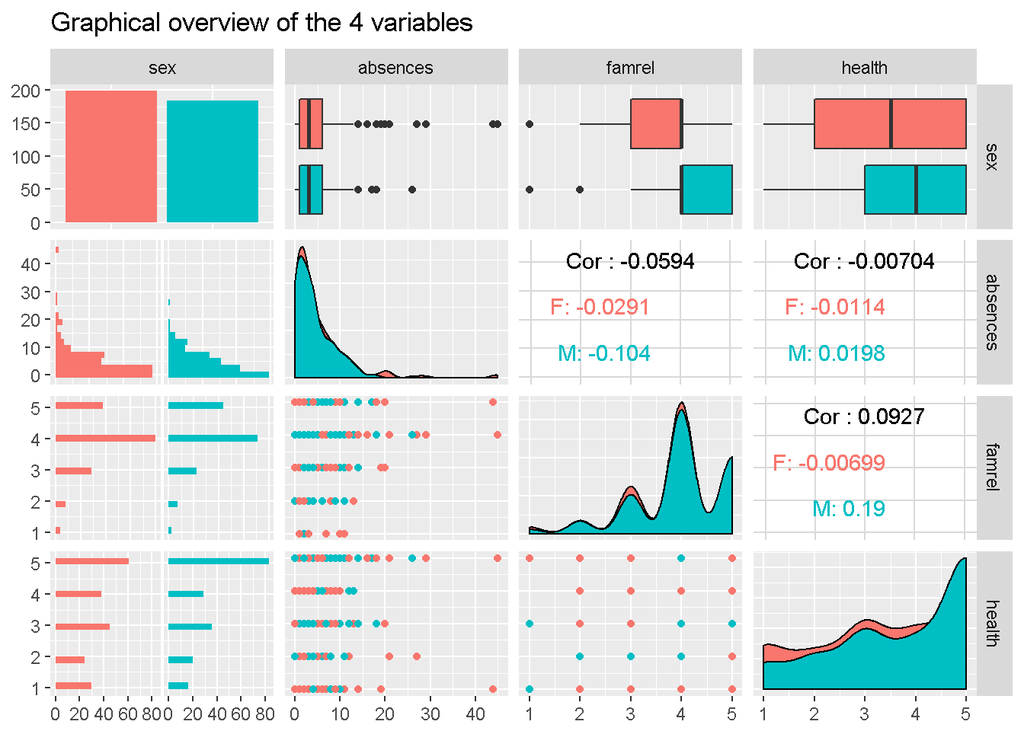

```r
#Matrix of plots
ggpairs(alc_study[-1], mapping = aes(col = sex), lower = list(combo = wrap("facethist", bins = 20)), title="Graphical overview of the 4 variables")
```

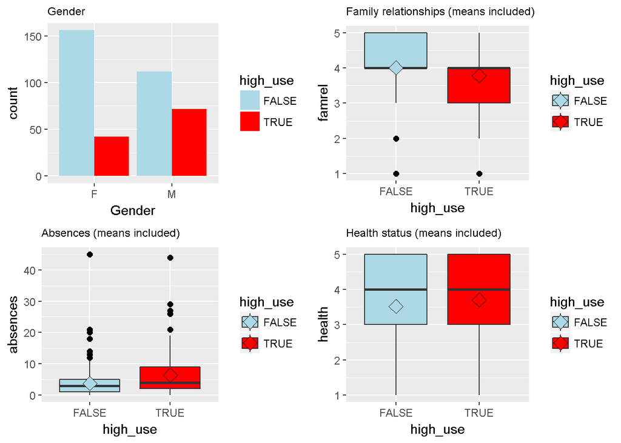

```r
p1 <- ggplot(alc_study, aes(sex)) + geom_bar(aes(fill = high_use), position = "dodge", stat="count") + xlab('Gender')+ggtitle("Gender") +scale_fill_manual(values=c("lightblue","red"))+
  theme(plot.title = element_text(size=9))



p2 <- ggplot(alc_study, aes(x=high_use,y= absences,fill=high_use)) + geom_boxplot(outlier.colour="black", outlier.shape=16,
             outlier.size=2, notch=FALSE) +
stat_summary(fun.y=mean, geom="point", shape=23, size=4)+ggtitle("Absences (means included)")+
scale_fill_manual(values=c("lightblue","red"))+
theme(plot.title = element_text(size=9))


p3 <- ggplot(alc_study, aes(x=high_use,y= famrel,fill=high_use)) + geom_boxplot(outlier.colour="black", outlier.shape=16,
             outlier.size=2, notch=FALSE) +
stat_summary(fun.y=mean, geom="point", shape=23, size=4)+ggtitle("Family relationships (means included)")+
scale_fill_manual(values=c("lightblue","red"))+
theme(plot.title = element_text(size=9))




p4 <- ggplot(alc_study, aes(x=high_use,y= health,fill=high_use)) + geom_boxplot(outlier.colour="black", outlier.shape=16,
             outlier.size=2, notch=FALSE) +
stat_summary(fun.y=mean, geom="point", shape=23, size=4)+ggtitle("Health status (means included)")+
scale_fill_manual(values=c("lightblue","red"))+
  theme(plot.title = element_text(size=9))



multiplot(p1, p2, p3, p4, cols = 2)
```

#### Grouped summary statistics and preliminary comments

In addition to data visualization, descriptive statistics are shown numerically as a summary grouped by *high_use* to get a preliminary, quantitative idea of the data set.In the package tableone the command CreateTableOne simultanously does group comparisons.

```r
#Summary

CreateTableOne(vars=c("sex","absences","famrel","health"), strata=c("high_use"),factorVars=c("sex"),data=alc_study )
```

```
##                       Stratified by high_use
##                        FALSE        TRUE         p      test
##   n                     268          114
##   sex = M (%)           112 (41.8)    72 (63.2)  <0.001
##   absences (mean (sd)) 3.71 (4.45)  6.37 (6.99)  <0.001
##   famrel (mean (sd))   4.00 (0.89)  3.78 (0.93)   0.027
##   health (mean (sd))   3.52 (1.40)  3.70 (1.40)   0.242
```

There are proportionally more male high users than there are females. Family relationships on average are better for the ones not using a lot of alcohol (4.00 vs 3.78). However, there are no differencies in the median values (4.00 vs 4.00). Both the mean (6.37) and median (4.00) values for absences are higher in the higher usage group than in the group of students consuming less than average amount (3.71,3.00). There are also quite a few outliers in both groups. Surprisingly, the high-user group members have higher current health scores (mean=3.70, median=4.00) than do the non-high-user ones (3.52,4.00). Yet, the differences are small.

Thus, based on both the graphical and numerical overviews it seems that all of the variables except health are at least to some extent associated with the level of alcohol consumption as I hypotesized. Additionally, it has been investigated that there are no relevant correlations between the chosen variables. To further explore the associations a logistic regression analysis is carried out.

### Fitting the model

A logistic regression model with four explanatory variables selected based on the preliminary interest is fitted to identify the ones related to *higher than average student alcohol consumption*. Logistic regression is basic approach for binary outcomes and its results provide probability estimates of the event happening (P(Y=1)).

```r
#First model with four explanatory variables
m1<-glm(high_use~sex+absences+famrel+health,data=alc_study,family="binomial")
summary(m1)
```

```
##
## Call:
## glm(formula = high_use ~ sex + absences + famrel + health, family = "binomial",
##     data = alc_study)
##
## Deviance Residuals:
##     Min       1Q   Median       3Q      Max
## -2.2557  -0.8609  -0.6151   1.0698   2.1157
##
## Coefficients:
##             Estimate Std. Error z value Pr(>|z|)
## (Intercept) -0.94806    0.58165  -1.630   0.1031
## sexM         1.00440    0.24498   4.100 4.13e-05 ***
## absences     0.09375    0.02264   4.141 3.45e-05 ***
## famrel      -0.30625    0.12864  -2.381   0.0173 *
## health       0.08331    0.08779   0.949   0.3426
## ---
## Signif. codes:  0 '***' 0.001 '**' 0.01 '*' 0.05 '.' 0.1 ' ' 1
##
## (Dispersion parameter for binomial family taken to be 1)
##
##     Null deviance: 465.68  on 381  degrees of freedom
## Residual deviance: 423.95  on 377  degrees of freedom
## AIC: 433.95
##
## Number of Fisher Scoring iterations: 4
```

The summary of the model confirm what could already be suspected based on the plots and numerical grouped summary. The variables sex, absences and famrel are significant at the 5 % level. The effect of health is not even borderline significant (p=0.3426). From the estimates it can also be captured that the correlation between family relationships and *high_use* is negative and the correlation between school absences and *high_use* is positive. Furthermore, being a male positively correlates with the outcome, i.e. increases the risk of being a high consumer of alcohol.

#### Odds, odds ratio and confidence intervals

To better understand the odds ratio which is used in logistic regression to quantify the relationship between an explanatory factor and the target variabe the term *odds* should be clarified. It is the probability divided by the opposite of that probability. Logically, the ratio of two odds is called *the odds ratio*.Odds higher than 1 mean that the factor is positively associated with event happening, and odds less than 1 refers to a negative, or, if the event is unwanted (e.g. death), a protective effect. To further complicate the matter, based on the primary equation, in the logistic regression model the target variable is not purely odds, but the log of odds. Thus, in the following table, firstly the odds are obtained by exponentiating the summary estimates and, secondly the profile likelihood-based confidence intervals are calculated by using the confint command from MASS package:

```r
cbind(OR, CI)
```

```
##                    OR     2.5 %    97.5 %
## (Intercept) 0.3874923 0.1218232 1.2018295
## sexM        2.7302676 1.6999004 4.4499308
## absences    1.0982852 1.0527088 1.1506747
## famrel      0.7362043 0.5708862 0.9470728
## health      1.0868775 0.9165274 1.2940911
```

Apart from the variable health, the confidence intervals do not include one, as suspected, referring to a statistically significant factor. If any given confidence interval would include 1 it would mean that the factor could have either a positive or a negative effect, or no effect at all on the risk of the outcome.

#### Second model

Next, the non-significant variable health is excluded and the model is fitted again.

```r
#Second model with three explanatory variables
m2<-glm(high_use~sex+absences+famrel,data=alc_study,family="binomial")
summary(m2)
```

```
##
## Call:
## glm(formula = high_use ~ sex + absences + famrel, family = "binomial",
##     data = alc_study)
##
## Deviance Residuals:
##     Min       1Q   Median       3Q      Max
## -2.1998  -0.8427  -0.6062   1.0845   2.1356
##
## Coefficients:
##             Estimate Std. Error z value Pr(>|z|)
## (Intercept) -0.71798    0.52862  -1.358   0.1744
## sexM         1.02877    0.24341   4.227 2.37e-05 ***
## absences     0.09351    0.02266   4.127 3.68e-05 ***
## famrel      -0.29090    0.12744  -2.283   0.0225 *
## ---
## Signif. codes:  0 '***' 0.001 '**' 0.01 '*' 0.05 '.' 0.1 ' ' 1
##
## (Dispersion parameter for binomial family taken to be 1)
##
##     Null deviance: 465.68  on 381  degrees of freedom
## Residual deviance: 424.86  on 378  degrees of freedom
## AIC: 432.86
##
## Number of Fisher Scoring iterations: 4
```

Now all of the variables in the model are significant at the 5 % level.

```r
Oddsratios_Confint
```

```
##                           2.5 %    97.5 %
## (Intercept) 0.4877368 0.1702903 1.3635949
## sexM        2.7976292 1.7476499 4.5467291
## absences    1.0980228 1.0524564 1.1504519
## famrel      0.7475910 0.5811204 0.9595347
```

The significant odds ratios reveal that the factorial variable (male) denoting the difference between the genders refers to a 2.8 (1.7 - 4.5) times higher odds for males to be high consumers of alcohol than females. The coefficient for males would actually be the intercept plus the estimate. with increasing absences the person is more likely to be a high alcohol consumer. And on the contrary, the better the family relationships the less likely the person is to be a high consumer of alcohol.

More specifically, to explain and interpret both the summary and the table with odds ratios and confidence intervals I take a more detailed look at the coefficient for absences, which is 0.09352. It can be interpreted as the expected change in log odds for a one-unit increase in the number of absences. The odds ratio can be calculated by exponentiating this value to get 1.0980288 which means that we expect to see about 10% increase in the odds of being in a high alcohol user, for a one-unit increase in absences.

### Predictive power

The second model will be used to explore the predictive power of the model:

```r
probabilities<-predict(m2,type="response")
predictions<-probabilities >0.5
# Add the probabilities
alc_study <- mutate(alc_study, probability = probabilities)
# Calculate a logical high use value based on probabilites.
alc_study <- mutate(alc_study, prediction = probability > 0.5)
table(high_use=alc_study$high_use,prediction=predictions) %>% addmargins %>% round(digits=2)
```

```
##         prediction
## high_use FALSE TRUE Sum
##    FALSE   256   12 268
##    TRUE     85   29 114
##    Sum     341   41 382
```

```r
table(high_use=alc_study$high_use,prediction=predictions) %>% prop.table %>% addmargins() %>% round(digits=2)
```

```
##         prediction
## high_use FALSE TRUE  Sum
##    FALSE  0.67 0.03 0.70
##    TRUE   0.22 0.08 0.30
##    Sum    0.89 0.11 1.00
```

There are 256 true negatives and 29 true positives, 85 false negatives and 12 false positives. To conclude, the model predicts high consumption less frequently than it really is as can be demonstrated graphically:

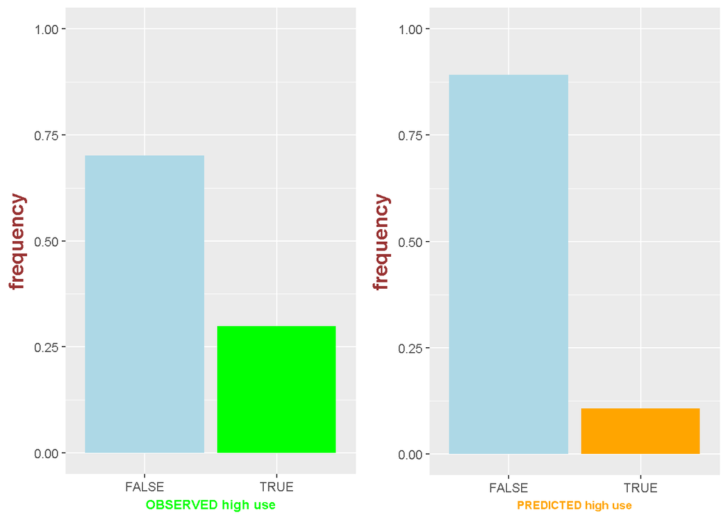

```r
hu <- as.data.frame(prop.table(table(alc_study$high_use)))
pred <- as.data.frame(prop.table(table(alc_study$prediction)))
pp1 <- ggplot(hu, aes(Var1, Freq)) + geom_col(aes(fill = Var1)) + scale_y_continuous(limits = 0:1) + ylab('frequency') + xlab('OBSERVED high use') + theme(legend.position = 'none')+
scale_fill_manual(values=c("lightblue","green"))+
 theme(
plot.title = element_text(color="green", size=14, face="bold.italic"),
axis.title.x = element_text(color="green", size=9, face="bold"),
axis.title.y = element_text(color="#993333", size=14, face="bold")
)

pp2 <- ggplot(pred, aes(Var1, Freq)) + geom_col(aes(fill = Var1)) + scale_y_continuous(limits = 0:1) + ylab('frequency') + xlab('PREDICTED high use') + theme(legend.position = 'none')+
scale_fill_manual(values=c("lightblue","orange"))+
 theme(
plot.title = element_text(color="red", size=14, face="bold.italic"),
axis.title.x = element_text(color="orange", size=8, face="bold"),
axis.title.y = element_text(color="#993333", size=14, face="bold")
)

multiplot(pp1, pp2, cols = 2)
```

Since we know how to make predictions with our model, we can also compute the average number of incorrect predictions. In our model it is 25.4% suggesting that the model is lacking accuracy.Logistic regression aims to minimize the incorrectly classified observations. However, the performance of the generated model is better than purely guessing or just tossing a coin, which has the probability of 50 % of predicting the one or another outcome.

```r
#loss_func from DataCamp exercises
loss_func<-function(class,prob){
  n_wrong<-abs(class-prob)>0.5
  mean(n_wrong)
}
loss_func(class = alc_study$high_use, alc_study$probability)#Training error of the three variable model
```

```
## [1] 0.2539267
```

### Cross validation

Cross-validation tests the model on unseen data, i.e. data not used for generating the model. The lower the value the more accurate the model. Cross-validation can also be used to compare models.

```r
#Errors computed and stored
cv <- cv.glm(data = alc_study, cost = loss_func, glmfit = m2, K = 10)
testerror<-cv$delta[1]
```

A ten-fold cross-validation shows that on average approximately 26% of the observations are missclassified under our model with three explanatory variables: sex, famrel and absencees. The average number of wrong predictions in the cross-validation is thus about the same as in the DataCamp exercise (26%).

However, if the goal of a study like this would be to identify, and thereafter to implement measures to control risk factors for high alcohol usage we would not succeed very well. It seems that the model is still missing relevant risk factors. Thus, I will try to improve the model by including another variable, namely age, in the model.

```r
mbetter<-glm(high_use~famrel+absences+sex+age,family=binomial,data=alc)
#Errors computed and stored
cvbetter <- cv.glm(data = alc, cost = loss_func, glmfit = mbetter, K = 10)
cvbetter$delta[1] # Print the average number of wrong predictions.
```

```
## [1] 0.2591623
```

Adding age to the model hardly improves the performance yielding just a little bit lower testing error.

### Further cross validation and model comparisons

#### Model with 12 variables

A data set with 11 integer and one factorial variable (gender) is used as a whole to improve the predictive accuracy.

```r
alcs<-alc[c("age","Medu","Fedu","failures","G3","sex","absences","famrel","health","goout","studytime","freetime","high_use")]
full<-glm(high_use~.,family=binomial,data=alcs)
#Errors computed and stored
cvfull <- cv.glm(data = alcs, cost = loss_func, glmfit = full, K = 10)
cvfull$delta[1] # Print the average number of wrong predictions.
```

```
## [1] 0.2356021
```

The full model based on this data set still has a reasonably high prediction error.

#### Model reduction

I choose not to compare model performance solely based on the number of variables, but rather based on the selection methods. To make a purposeful selection and model comparisons firstly stepAIC() and thereafter bestglm() are used. More information about the selection methods can be found in an article [here](https://www.ncbi.nlm.nih.gov/pmc/articles/PMC4842399/).

```r
library(leaps)
library(MASS)
library(bestglm)
scope<-stepAIC(full,scope=list(lower=~sex+absences+famrel,upper=full),trace=FALSE)
scope$anova
```

```
## Stepwise Model Path
## Analysis of Deviance Table
##
## Initial Model:
## high_use ~ age + Medu + Fedu + failures + G3 + sex + absences +
##     famrel + health + goout + studytime + freetime
##
## Final Model:
## high_use ~ sex + absences + famrel + goout + studytime
##
##
##         Step Df   Deviance Resid. Df Resid. Dev      AIC
## 1                                369   369.5715 395.5715
## 2       - G3  1 0.02581712       370   369.5973 393.5973
## 3 - failures  1 0.32319318       371   369.9205 391.9205
## 4 - freetime  1 0.60688507       372   370.5274 390.5274
## 5     - Fedu  1 0.55002583       373   371.0774 389.0774
## 6     - Medu  1 0.16331742       374   371.2407 387.2407
## 7      - age  1 1.06533948       375   372.3061 386.3061
## 8   - health  1 1.67027019       376   373.9764 385.9764
```

```r
bestglm(alcs,IC="BIC",family=binomial)
```

```
## Morgan-Tatar search since family is non-gaussian.
```

```
## BIC
## BICq equivalent for q in (0.268888789905018, 0.514103143659991)
## Best Model:
##                Estimate Std. Error   z value     Pr(>|z|)
## (Intercept) -2.76826342 0.66169773 -4.183577 2.869578e-05
## sexM         1.01234164 0.25894570  3.909475 9.249710e-05
## absences     0.08167686 0.02199598  3.713263 2.046039e-04
## famrel      -0.39378406 0.14034903 -2.805748 5.019988e-03
## goout        0.76761101 0.12316480  6.232389 4.593740e-10
```

Based on the outputs of the two approaches best models are fitted. The former (AIC) one includes gender, absences, family relationships, going out with friends and study time and the latter (bestglm) gender, absences, family relationships and going out with friends.

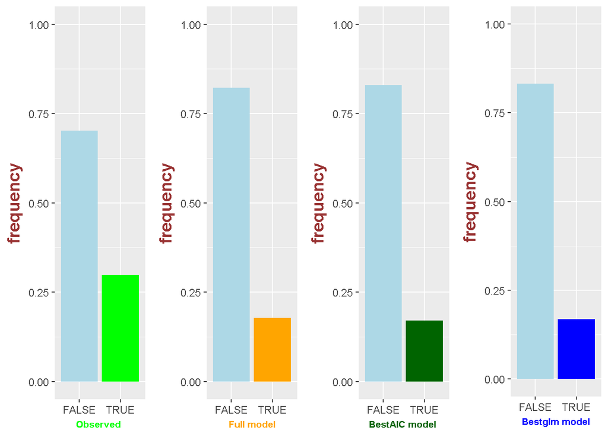

| Model | Training error | Test error |
| --- | --- | --- |
| **FULL model with 12 variables** | 0.2094241 | 0.2329843 |
| **AIC model with 5 variables** | 0.2172775 | 0.2225131 |
| **BEST model with 4 variables** | 0.2041885 | **0.2198953** |

```r
hu <- as.data.frame(prop.table(table(alcs$high_use)))
predfull <- as.data.frame(prop.table(table(alcsfull$prediction)))
predAIC <- as.data.frame(prop.table(table(alcsAIC$prediction)))
predbest <- as.data.frame(prop.table(table(alcsbest$prediction)))

ppobs <- ggplot(hu, aes(Var1, Freq)) + geom_col(aes(fill = Var1)) + scale_y_continuous(limits = 0:1) + ylab('frequency') + xlab('Observed ') + theme(legend.position = 'none')+
scale_fill_manual(values=c("lightblue","green"))+
 theme(
plot.title = element_text(color="green", size=14, face="bold.italic"),
axis.title.x = element_text(color="green", size=8, face="bold"),
axis.title.y = element_text(color="#993333", size=14, face="bold")
)

ppfull <- ggplot(predfull, aes(Var1, Freq)) + geom_col(aes(fill = Var1)) + scale_y_continuous(limits = 0:1) + ylab('frequency') + xlab('Full model') + theme(legend.position = 'none')+
scale_fill_manual(values=c("lightblue","orange"))+
 theme(
plot.title = element_text(color="red", size=14, face="bold.italic"),
axis.title.x = element_text(color="orange", size=8, face="bold"),
axis.title.y = element_text(color="#993333", size=14, face="bold")
)

ppAIC <- ggplot(predAIC, aes(Var1, Freq)) + geom_col(aes(fill = Var1)) + scale_y_continuous(limits = 0:1) + ylab('frequency') + xlab('BestAIC model ') + theme(legend.position = 'none')+
scale_fill_manual(values=c("lightblue","darkgreen"))+
 theme(
plot.title = element_text(color="red", size=14, face="bold.italic"),
axis.title.x = element_text(color="darkgreen", size=8, face="bold"),
axis.title.y = element_text(color="#993333", size=14, face="bold")
)

ppbest<- ggplot(predbest, aes(Var1, Freq)) + geom_col(aes(fill = Var1)) + scale_y_continuous(limits = 0:1) + ylab('frequency') + xlab("Bestglm model") + theme(legend.position = 'none')+
scale_fill_manual(values=c("lightblue","blue"))+
 theme(
plot.title = element_text(color="blue", size=14, face="bold.italic"),
axis.title.x = element_text(color="blue", size=8, face="bold"),
axis.title.y = element_text(color="#993333", size=14, face="bold")
)

multiplot(ppobs, ppfull, ppAIC, ppbest,cols = 4)
```

#### Final model with the lowest testing error

```r
probabilities<-predict(mbest,type="response")
predictions<-probabilities >0.5
# Add the probabilities
alcbest <- mutate(alcs, probability = probabilities)
# Calculate a logical high use value based on probabilites.
alcbest <- mutate(alcbest, prediction = probability > 0.5)
table(high_use=alcbest$high_use,prediction=predictions) %>% addmargins %>% round(digits=2)
```

```
##         prediction
## high_use FALSE TRUE Sum
##    FALSE   254   14 268
##    TRUE     64   50 114
##    Sum     318   64 382
```

To conclude, the results of the final model as odds ratios with th corresponding confidence intervals:

```r
stargazer(mbest, coef = list(OR.vector), ci = T,
          ci.custom = list(CI.vector), p = list(p.values),
          single.row = T,align=TRUE, type = "html",

          title="Logistic regression model: Variables related to alcohol consumption",column.labels=c("odds ratio(confint)"),
          covariate.labels=c("Gender(M)","School absences","Family relationships","Going out with friends"),
          dep.var.caption = "Model with the lowest testing error",
          dep.var.labels = "Dependent variable:More than average alcohol usage" )
```

**Logistic regression model: Variables related to alcohol consumption**

|  | Model with the lowest testing error |
| --- | --- |
|  | Dependent variable:More than average alcohol usage |
|  | odds ratio(confint) |
| Gender(M) | 2.752*** (1.668, 4.613) |
| School absences | 1.085*** (1.040, 1.135) |
| Family relationships | 0.674*** (0.511, 0.887) |
| Going out with friends | 2.155*** (1.703, 2.764) |
| Constant | 0.063*** (0.016, 0.223) |
| Observations | 382 |
| Log Likelihood | -189.904 |
| Akaike Inf. Crit. | 389.809 |
| *Note:* | p<0.1; p<0.05; p<0.01 |

Ref. Fabio Pagnotta’s and Hossain Mohammad Amran’s Using Data Mining To Predict Secondary School Student Alcohol Consumption (2008), published by Department of Computer Science of the University of Camerino